# Spatial data tutorial

Andrea Brown

10/11/2022

Here we will manipulate and plot data from the the Waterfowl Breeding Population and Habitat Survey (WBPHS). You can get more information about WBPHS from [here](https://www.canada.ca/en/environment-climate-change/services/bird-surveys/waterfowl/breeding-population-habitat-survey.html) and download the data [here](https://www.fws.gov/project/waterfowl-breeding-population-and-habitat-survey).

Install and load R packages.

```r
# install.packages(c("raster", "sf", "sp", "rgdal", "ggplot2", "ggspatial", "rnaturalearth", "wesanderson"))
```

```r
library(dplyr) ## for data manipulation
library(raster) ## for using raster data
library(sf) ## simple features "sf" for spatial data
library(sp) ## for using spatial data
library(ggplot2) ## for plotting
library(ggspatial) ## plot maps using ggplot
library(rnaturalearth) ##
```

First, we need to read in our data. We are using raster data of the Canada and USA outlines as the reference CRS (Coordinate refence system). We have shapefiles for our study area and transect segments.

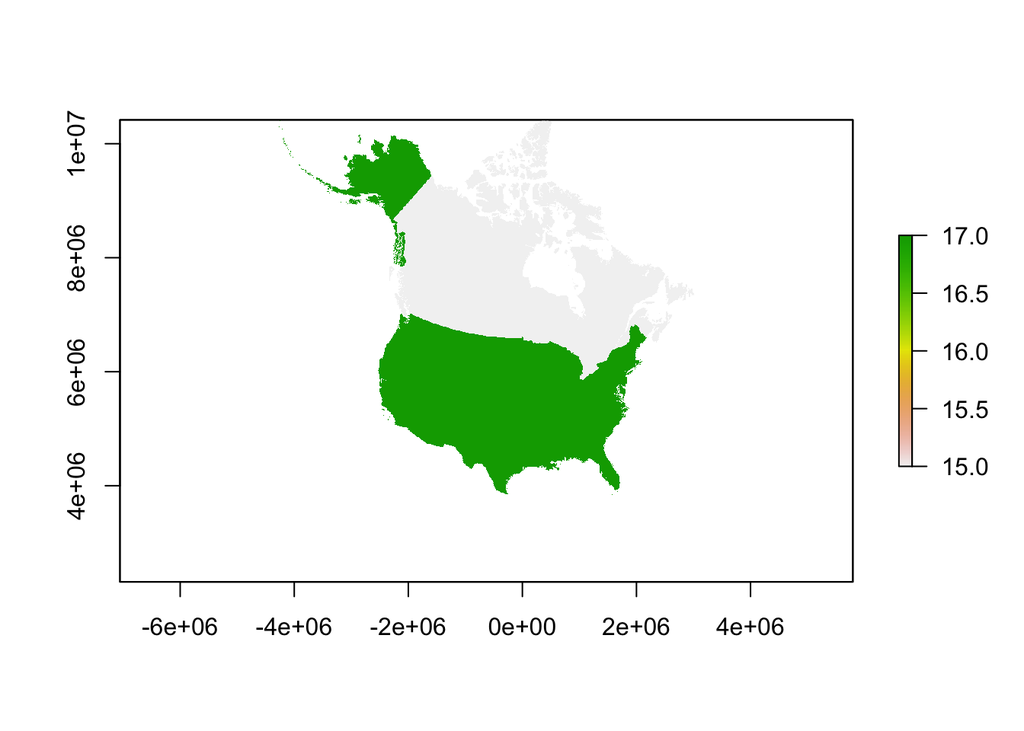

```r
canusa <- raster("data/USCanadaOutline.tif")
crs(canusa)
plot(canusa)
```

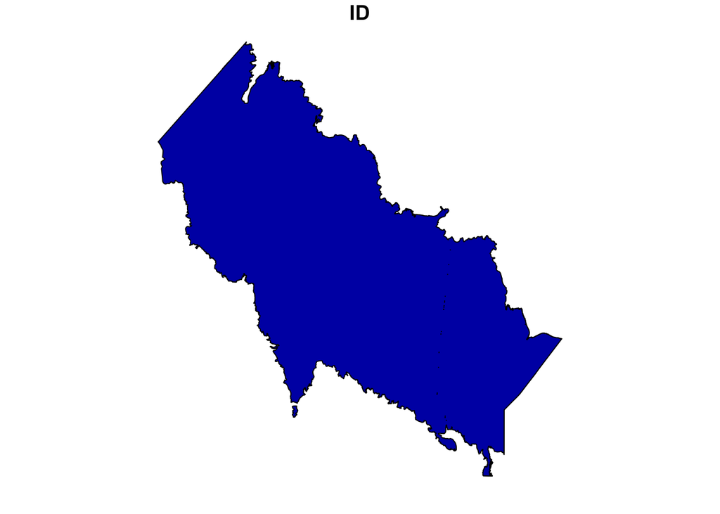

```r
study <- st_read("data/WBI shapefile/WBI Study Area.shp")
plot(study)
```

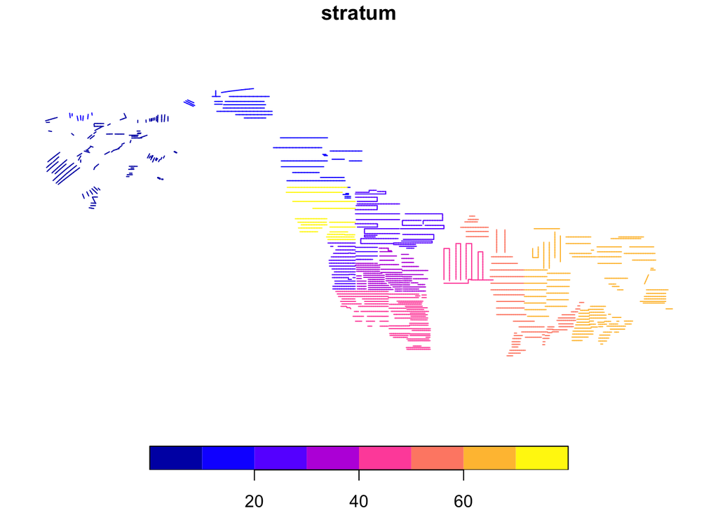

```r
segments <- st_read("data/WBPHS shapefile/MAS_segments.shp")
segments <- segments %>%
  dplyr::select(stratum)
plot(segments)
```

So we’ve plotted our based raster of Canada & US, the western boreal forest polygon and the WBPHS aerial survey transects (segments). We only really need the geometry of each segment, but to see what the segments look like we just plotted the *stratums*, which are the different survey plots used by WBPHS.

Here we plotted all the WBPHS aerial survey transects.

Next we will set the crs of the western boreal forests shapefile to be the same as the `canusa` object we created above.

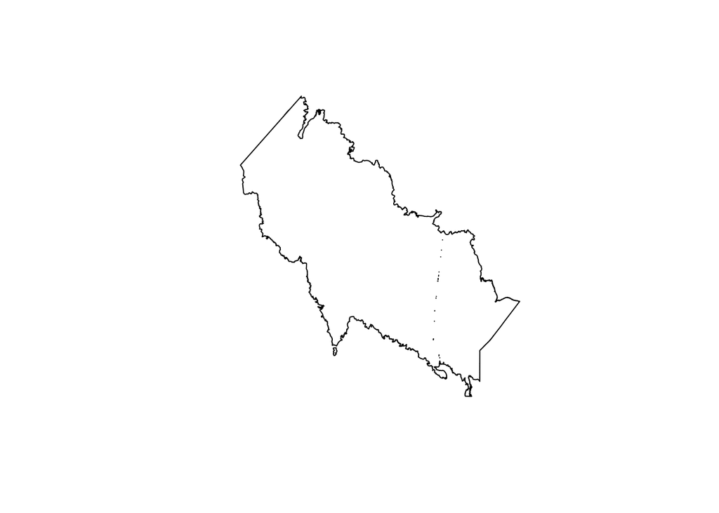

```r
# set crs to be the same as canusa
study_sp <- st_transform(study, crs = st_crs(canusa))
plot(st_geometry(study_sp)) # to plot outline of study area
```

Let’s plot a 500 km buffer around study area – something we’ll want to do later with our own data.

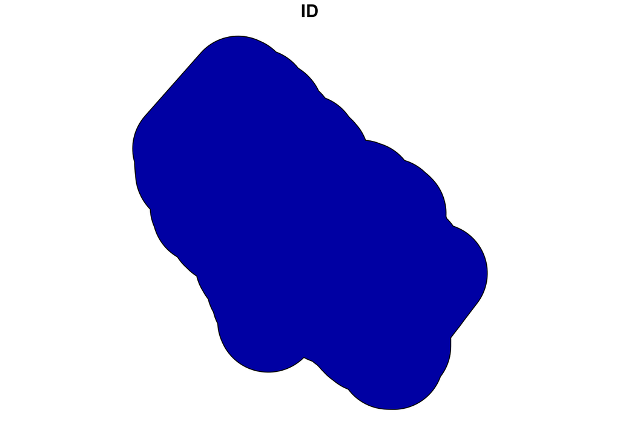

```r
study_buf <- st_buffer(study_sp, dist = 500000)
plot(study_buf)
```

```r
rm(study) # we no longer need this object, remove from R environment
```

Convert segments to same crs, and crop segments to buffered study area. You can use can `st_crop()` BUT it only crops to the maximum extent of the buffered study area (crops to a rectangle); to crop to the actual polygon we use `st_intersection()`.

```r
# convert crs of segments to the same are canusa
seg_sp <- st_transform(segments, crs(canusa))

st_crs(seg_sp) == st_crs(study_buf) # make sure they have the same crs before cropping
```

```
## [1] TRUE
```

```r
seg_crop <- st_intersection(seg_sp, study_buf)
```

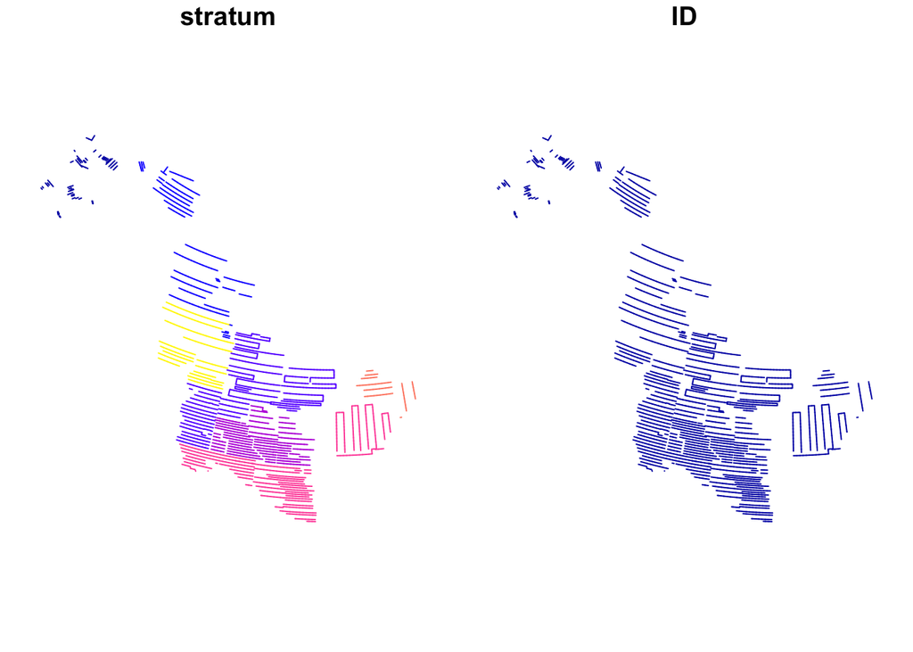

```r
plot(seg_crop)
```

```r
rm(segments, seg_sp)
```

Let’s plot everything together using base R.

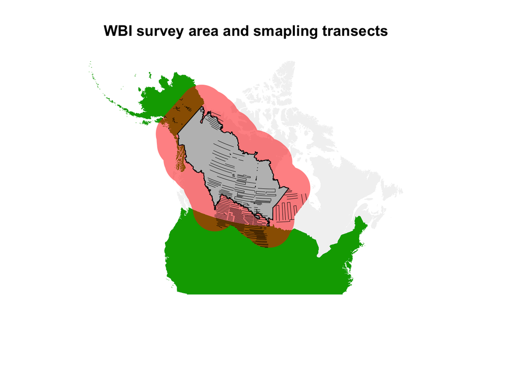

```r
plot(canusa, ext = c(-5e+06, 5e+06, 5e+06, 4e+07), axes=F, box=F, legend = F)
plot(study_buf, col= alpha("red", 0.5), border = "transparent", add = T)
plot(study_sp, col = "grey", add = T)
plot(seg_crop, col = "black", lwd = 0.5, add = T)
title(main = "WBI survey area and smapling transects")
```

This is nice but we can do better. Lets plot the same map using ggplot.

First we need to make the study area, buffered area and transects into sf (it’s easier to work with in ggplot).

```r
# study area
study_sp2 <- st_as_sf(study_sp)
# buffered study area
study_buf2 <- st_as_sf(study_buf)
# cropped segments
seg_crop2 <- st_as_sf(seg_crop)
```

Next, we get the base map from *rnaturalearth* and filter and zoom in on Canada.

```r
# Get a shapefile of all countries from the rnaturalearth package
world <- ne_countries(scale = "medium",
                      returnclass = "sf")
# filter for the countries you want for your plot
world <- world %>%
  subset(continent == "North America",
         adm0_a3 == "CAN" | adm0_a3 == "USA")
# change crs to be the same as the study area, buffered study area and segments
world <- st_transform(world, crs(study_sp2))
# set bounding box the zoom in on North America, you can play around with these numbers to zoom in or out
box <- c(xmin = -3717148, xmax = 2558043.4, ymin = 5886034, ymax = 11860535.3)
# crop world shpaefile to your bouding box
world <- st_crop(world, box)
```

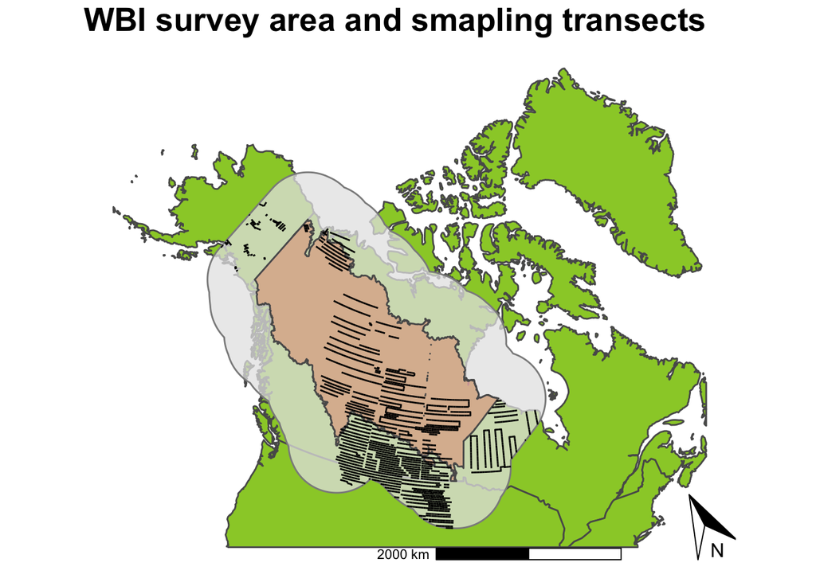

```r
# plot!
ggplot() +
  geom_sf(data = world, aes(geometry = geometry), fill = "yellowgreen", size =0.5) +
  geom_sf(data = study_buf2,
          aes(geometry = geometry),
          fill = "grey90", alpha = 0.75, color = "grey55") +
  geom_sf(data = study_sp2, aes(geometry = geometry), show.legend = F,
          fill = "red", alpha = 0.2) +
  geom_sf(data = seg_crop2,aes(geometry = geometry),
          show.legend =  F) +
  annotation_scale(location = "br", width_hint = 0.3, pad_x = unit(2.5, "cm")) +
  annotation_north_arrow(which_north = "true", location = "br", width = unit(0.95, "cm"),
                         pad_x = unit(0.2, "cm")) +
  ggthemes::theme_map() +
  labs(title = "WBI survey area and smapling transects") +
  theme(plot.title = element_text(size = 20, face = "bold"))
```